# Projeto Insper Data

#### Análise gráfica

Através dos dados do painel COVID, o gráfico mostra o número de municípios com algum caso de coronavírus através dos dias.

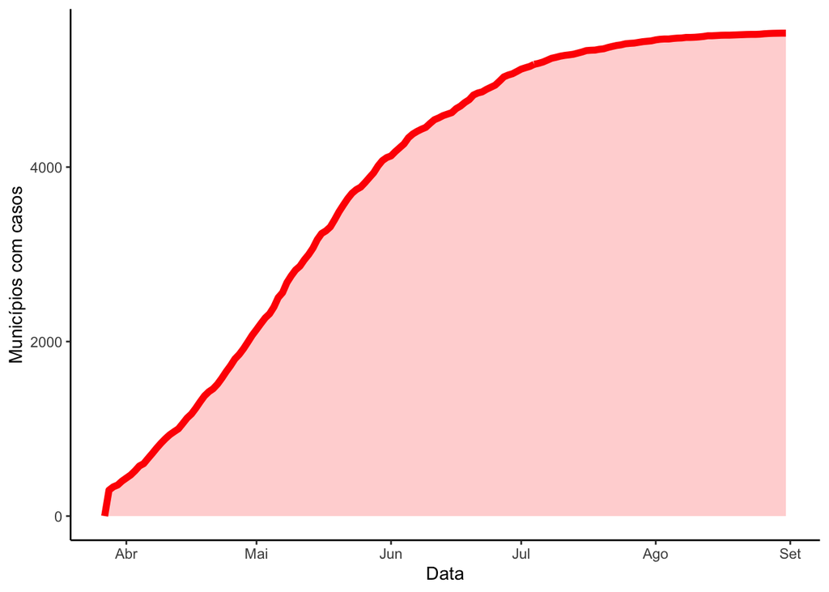

```
## $title
## [1] "Número de municípios com casos ao longo do ano de 2020"
##
## attr(,"class")
## [1] "labels"
```

Gráfico de dispersão mostrando a distribuição da mortalidade excessiva média de cada município pelo log do PIB per capita (excluindo alguns outliers com números muito elevados).

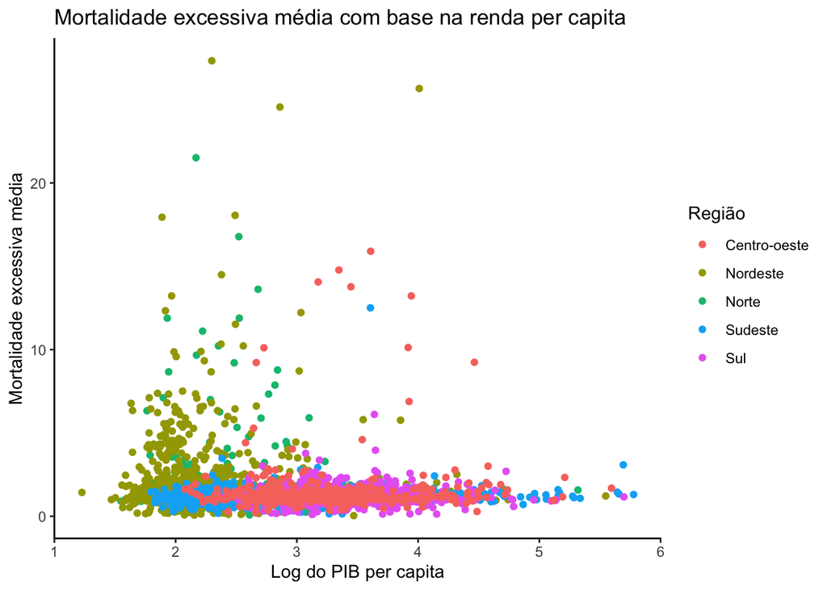

```
## List of 1
##  $ legend.position: chr "null"
##  - attr(*, "class")= chr [1:2] "theme" "gg"
##  - attr(*, "complete")= logi FALSE
##  - attr(*, "validate")= logi TRUE
```

Gráfico que mostra evolução do excesso de mortalidade no ano de 2020, por nível de renda. Podemos perceber uma tendência paralela no período pré-pandemia (meses de janeiro, fevereiro e março), apesar de os municípios mais pobres já apresentarem um excesso de mortalidade mais elevado.

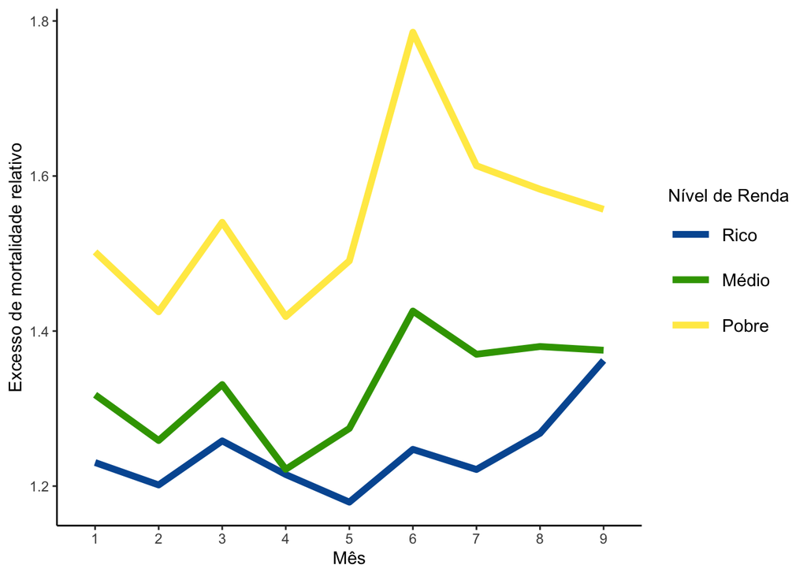

Gráficos mostrando a média da mortalidade excessiva no pré e pós-tratamento, dividindo por nível de renda.

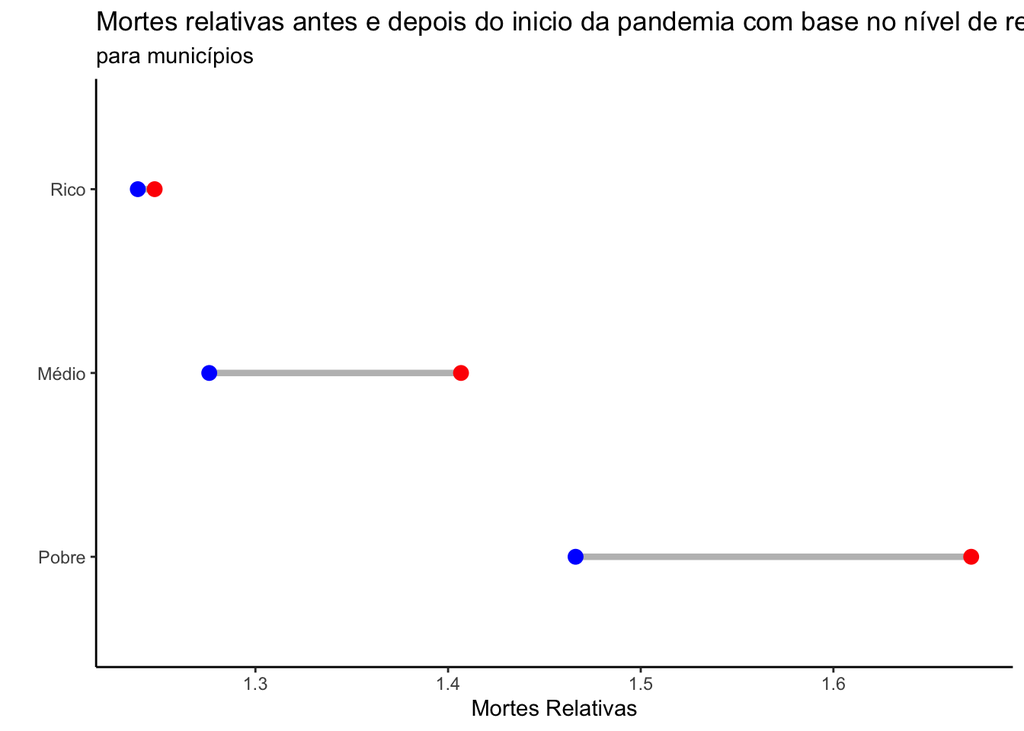

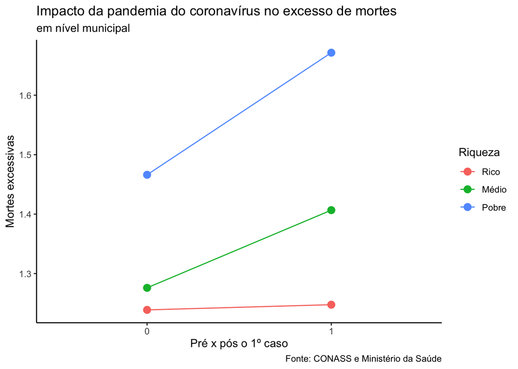

#### Mapas

Mapa do Brasil, dividindo os municípios pelo nível de renda.

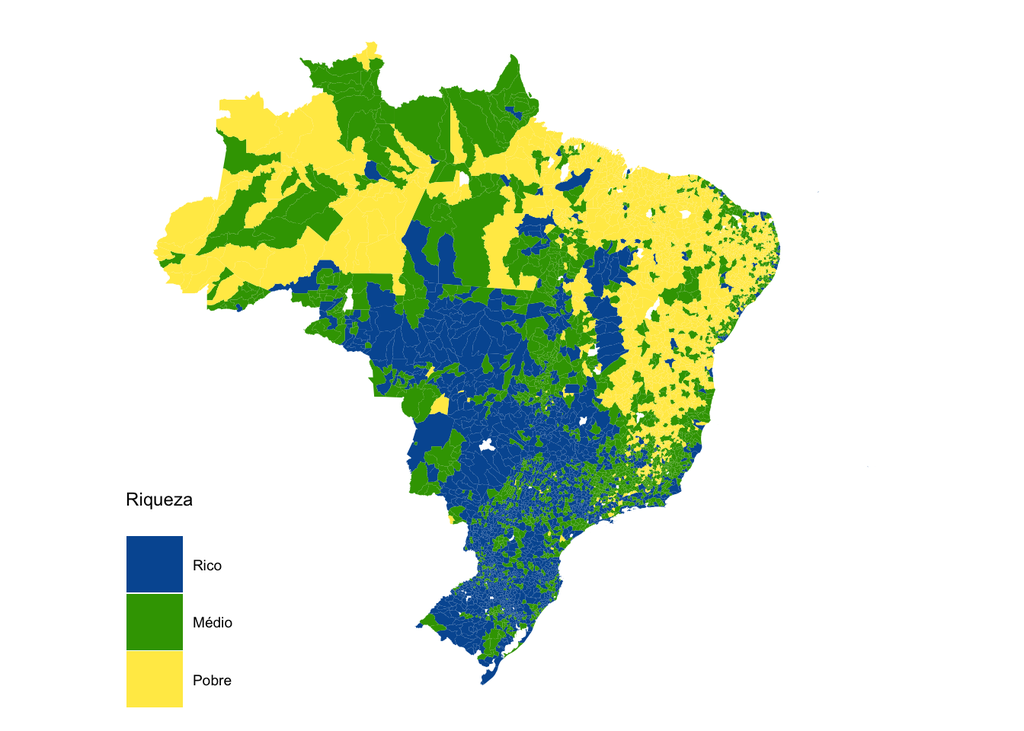

Mapa das regiões metropolitanas e não metropolitanas.

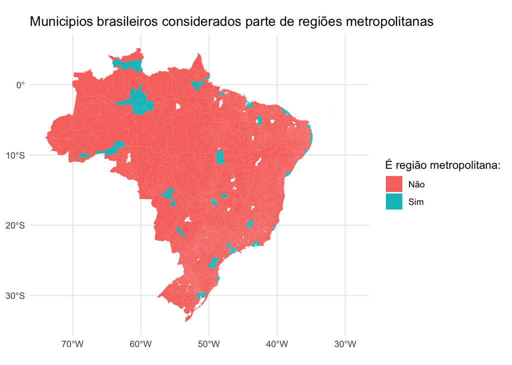